# Prediction in Sentiment Analysis - Amazon Sample

Results - Insights - Methodology

Philippe Lambot

April 14, 2020

## *********************************************************************************

## PREDICTION IN SENTIMENT ANALYSIS - AMAZON SAMPLE

## *********************************************************************************

## I. EXECUTIVE SUMMARY

GITHUB: https://github.com/Dev-P-L/Sentiment-Analysis

## II. FOREWORD to READERS

Dear Readers, you are most welcome to run the project on your own computer if you so wish.

This project is lodged with the GitHub repository https://github.com/Dev-P-L/Sentiment-Analysis.

You can knit SA_Amazon_Code.Rmd (please in HTML) and produce SA_Amazon_Insights&Results.html on your own computer. On my laptop, running SA_Amazon_Code.Rmd takes approximately four hours. For information, here are some characteristics of my work environment:

- R version 3.5.1 (2018-07-02) – “Feather Spray”,
- RStudio Version 1.1.456,
- Windows 10.

Some packages are required in SA_Amazon_Code.Rmd. The code from SA_Amazon_Code.Rmd contains instructions to download these packages if they are not available yet.

Now, let’s get in touch with data.

## III. GETTING IN TOUCH with DATA

## Exploratory analysis

### A. Prevalence

```
## [1] "Popular"   "Unpopular"
```

|  | Popular | Unpopular |
| --- | --- | --- |
| Training Set | 728 | 3626 |

```
##              Popular Unpopular
## Training Set     728      3626
```

Positive class is a clear minority, which justifies not relying on accuracy metric to measure predictive performance.

|  | Prevalence of Positive Class (“Popular”) |
| --- | --- |
| Training Set | 17 % |

Prevalence of positive class is 17 %.

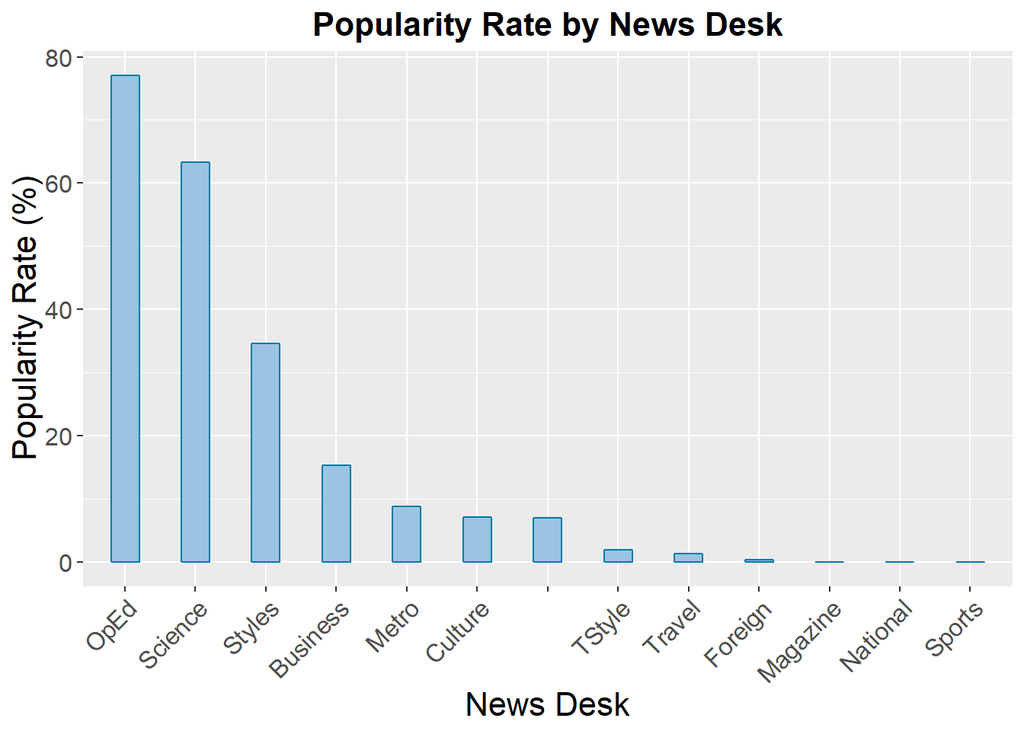

There is clear-cut difference between some categories: OpEd and Science are on top, much above 50 % and other categories are much lower.

| News Desk | Occurrence | Popularity Percentage |
| --- | --- | --- |
| OpEd | 358 | 77 % |
| Science | 131 | 63 % |
| Styles | 194 | 35 % |
| Business | 1058 | 15 % |
| Metro | 136 | 9 % |
|  | 1231 | 7 % |
| Culture | 437 | 7 % |
| TStyle | 460 | 2 % |
| Travel | 76 | 1 % |
| Foreign | 255 | 0 % |
| Magazine | 14 | 0 % |
| National | 3 | 0 % |
| Sports | 1 | 0 % |

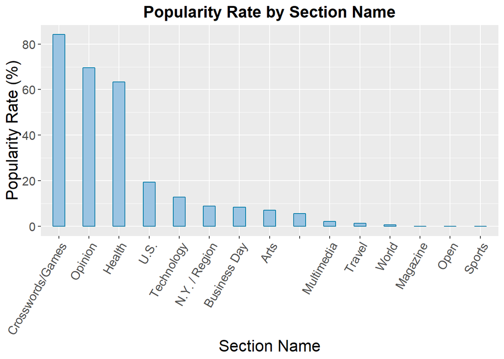

[output not shown]

There is clear-cut difference between some categories: Crosswords/Games, Opinion and Health are on top, above 50 % and other categories are much lower.

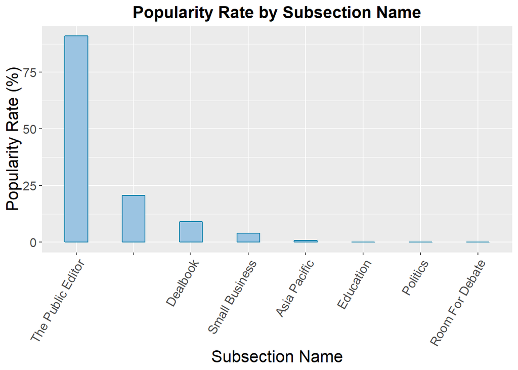

| Subsection Name | Occurrence | Popularity Percentage |
| --- | --- | --- |
| The Public Editor | 11 | 91 % |
|  | 3184 | 21 % |
| Dealbook | 650 | 9 % |
| Small Business | 100 | 4 % |
| Asia Pacific | 146 | 1 % |
| Education | 222 | 0 % |
| Politics | 2 | 0 % |
| Room For Debate | 39 | 0 % |

..

|  | ILLUSTRATIVE SAMPLE OF HEADLINES |
| --- | --- |
| Training Set Row Number 1157 | Sky-High Rolling in Las Vegas |
| Training Set Row Number 1620 | 10 Ways to Explore and Express What Makes Your Community Unique |
| Training Set Row Number 2494 | Globalfest 2015 Will Offer a Broad View of World Music |

…

|  | ILLUSTRATIVE SAMPLE OF ABSTRACTS |
| --- | --- |
| Training Set Row Number 1157 | The High Roller in Las Vegas gives visitors an opportunity to celebrate above it all. |
| Training Set Row Number 1620 | What communities are you a part of? Which one matters to you most? What do people need to know about this community? How can you communicate that? Here are some ideas for projects for teachers and stu… |
| Training Set Row Number 2494 | The one-day festival, now in its 12th year, will bring together musical styles from all corners of the globe in January. |

..

|  | ILLUSTRATIVE SAMPLE OF SNIPPETS |
| --- | --- |
| Training Set Row Number 1157 | The High Roller in Las Vegas gives visitors an opportunity to celebrate above it all. |
| Training Set Row Number 1620 | What communities are you a part of? Which one matters to you most? What do people need to know about this community? How can you communicate that? Here are some ideas for projects for teachers and stu… |
| Training Set Row Number 2494 | The one-day festival, now in its 12th year, will bring together musical styles from all corners of the globe in January. |

Consequently, should snippets be taken into account or should that predictor be discarded? How many snippets differ from abstracts because some words have been dropped?

|  | Snippets Differing from Abstracts |
| --- | --- |
| Number in Training Set | 62 |
| Proportion in Training Set | 1.42 % |

Snippets differing from abstracts are underrepresented. The vast majority of snippets are strictly identical to abstracts. Consequently, only one out of the two predictors will be kept. Should it be abstracts because in a tiny minority of cases they contain some additional words? Not necessarily because readers could pay more attetion to snippets. Actually, both predictors will be tried separately and the one that outperforms the other will be kept.

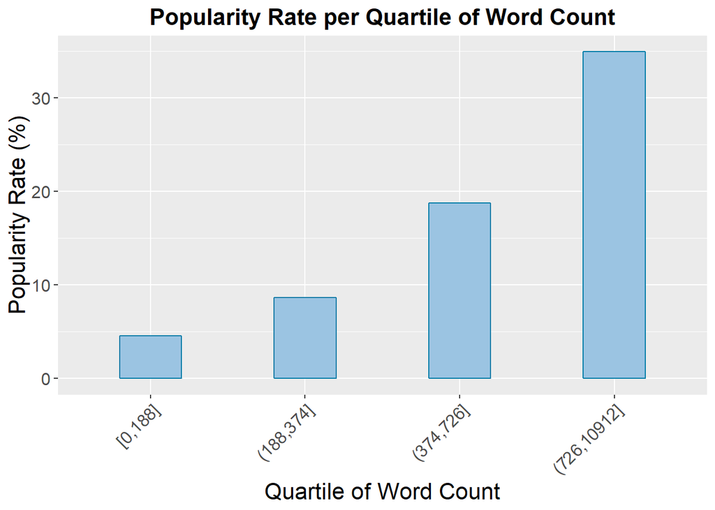

The graph above is insightful: measured per quartile of WordCount, popularity rate is strictly and substantially increasing with the word count. Moreover, differences are statistically significant since each average popularity rate refers to appoximately one fourth of the training set. Consequently, Word count will be used as a predictor in Machine Learning.

Graph with popularity average per month.

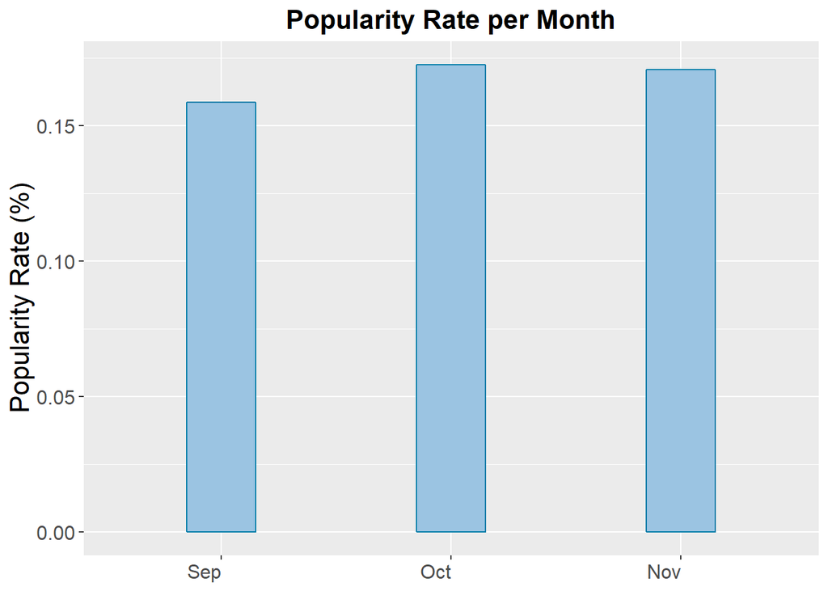

Differences per month being Lilliputian, this predictor will not be added to the training set. Let’s now have a try with days of the week.

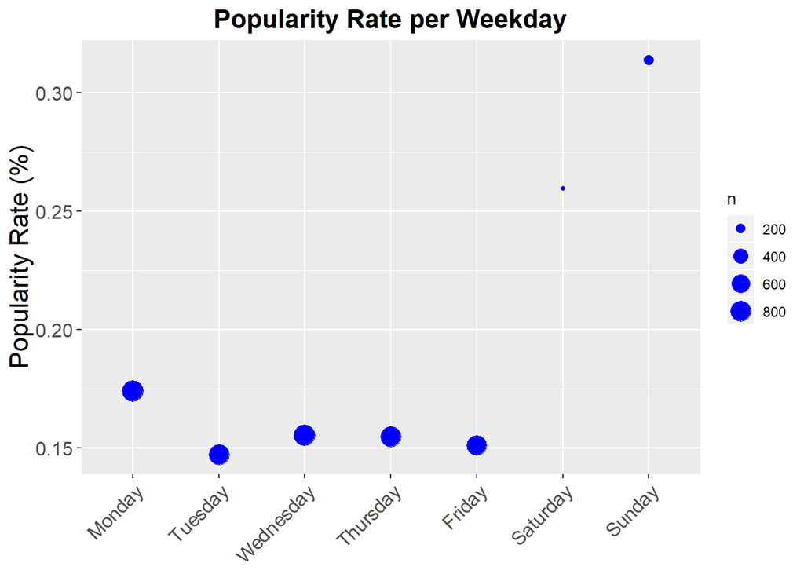

There is a clear difference between weekend and other weekdays: popularity rate is substantially higher during weekend, and especially on Sundays. But are higher average popularity rates statistically representative, in other words are there enough observations for Saturday and Sunday so that their averages can be taken into account?

| Weekday | Occurrence | Popularity Percentage |
| --- | --- | --- |
| Sunday | 207 | 31.4 % |
| Saturday | 131 | 25.95 % |
| Monday | 834 | 17.39 % |
| Wednesday | 850 | 15.53 % |
| Thursday | 788 | 15.48 % |
| Friday | 742 | 15.09 % |
| Tuesday | 802 | 14.71 % |

The table above relativizes the predictive power of that predictor since higher average popularity rates relate to smaller numbers of observations in the training set. Nevetherless, the numbers for Saturday and Sunday remain statistically significant and this predictor will be added as well to the training set.

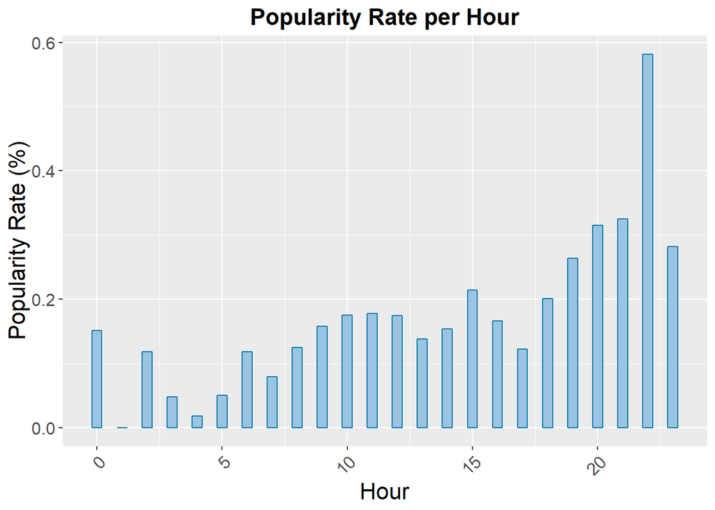

But are the lowest and highest average popularity rates statistically representative? Let’s have a look at a breakdown of observations per hour in a 24-hour clock system.

| Hour | Occurrence | Popularity Percentage |
| --- | --- | --- |
| 22 | 98 | 58.2 % |
| 21 | 77 | 32.5 % |
| 20 | 111 | 31.5 % |
| 23 | 39 | 28.2 % |
| 19 | 129 | 26.4 % |
| 15 | 290 | 21.4 % |
| 18 | 209 | 20.1 % |
| 11 | 337 | 17.8 % |
| 10 | 257 | 17.5 % |
| 12 | 344 | 17.4 % |
| 16 | 295 | 16.6 % |
| 9 | 222 | 15.8 % |
| 14 | 293 | 15.4 % |
| 0 | 86 | 15.1 % |
| 13 | 297 | 13.8 % |
| 8 | 241 | 12.4 % |
| 17 | 254 | 12.2 % |
| 2 | 17 | 11.8 % |
| 6 | 152 | 11.8 % |
| 7 | 254 | 7.9 % |
| 5 | 179 | 5 % |
| 3 | 42 | 4.8 % |
| 4 | 113 | 1.8 % |
| 1 | 18 | 0 % |

Observations are more concentrated in the middle of the empirical distribution. Nevertheless, even extreme rates remain statistically representative, such as the highest rate at almost 60 % or the lowest rates below 5 %, if not taken separately at least taken together. This predictor will also be included into the training set.

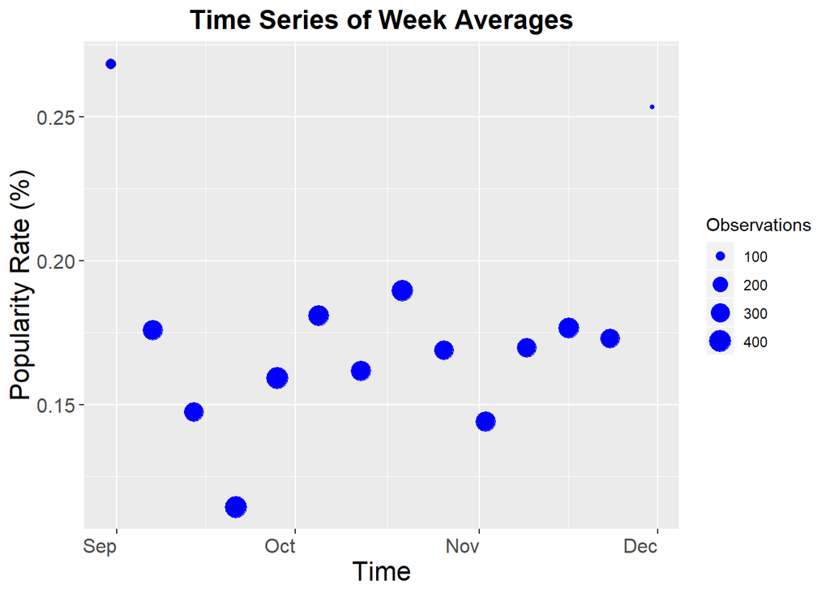

Fluctuations are rather limited except for two points. Let’s digitalize in the following table.

| Week | Occurrence | Popularity Percentage |
| --- | --- | --- |
| 2014-08-31 | 108 | 26.9 % |
| 2014-11-30 | 75 | 25.3 % |
| 2014-10-19 | 369 | 19 % |
| 2014-10-05 | 365 | 18.1 % |
| 2014-11-16 | 351 | 17.7 % |
| 2014-09-07 | 341 | 17.6 % |
| 2014-11-23 | 318 | 17.3 % |
| 2014-11-09 | 324 | 17 % |
| 2014-10-26 | 314 | 16.9 % |
| 2014-10-12 | 346 | 16.2 % |
| 2014-09-28 | 396 | 15.9 % |
| 2014-09-14 | 319 | 14.7 % |
| 2014-11-02 | 326 | 14.4 % |
| 2014-09-21 | 402 | 11.4 % |

Together, the highest averages correspond to almost 200 observations but these averages are not that high in comparison with other ones. Moreover, even if the highest averages were towering above the other ones, using a time series dimension would probably only make sense because here the validation relates to the same period. This predictor will not be included into the training set.

NLP Corpus: headlines and snippets As a pre-attentive insight, a wordcloud will show the most frequent tokens.

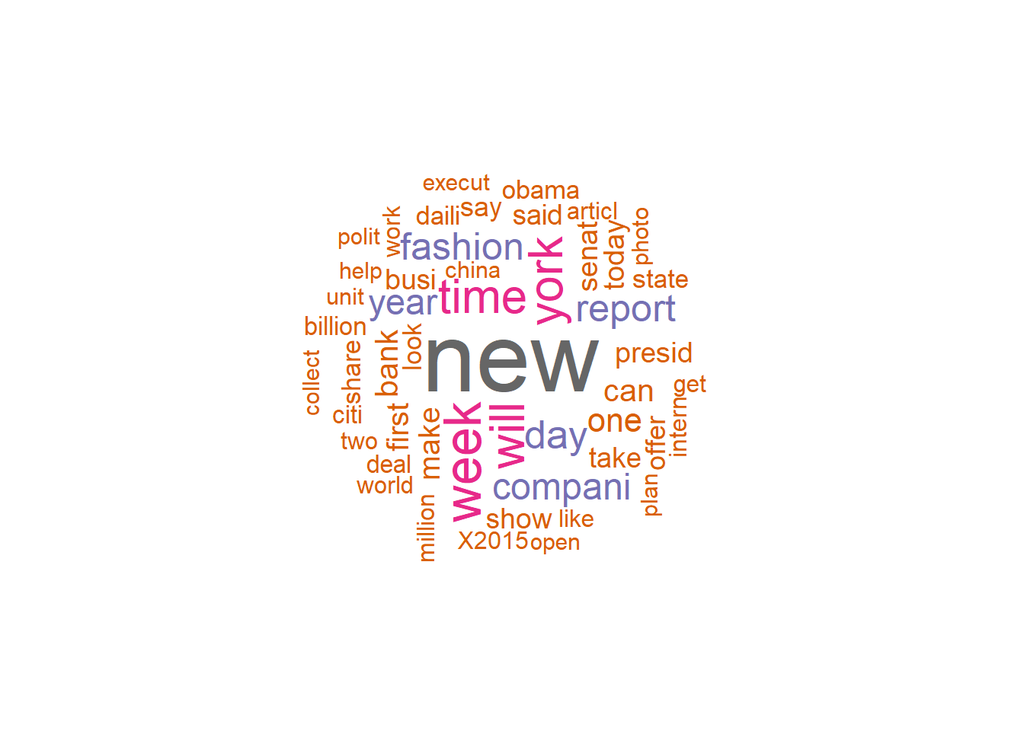

Let’s add the bag of words to the training set, the columns from the Document Term Matrix to the training set.

Machine learning on train.

```
## [1] 0.8971061
```

```
## Confusion Matrix and Statistics
##
##            Reference
## Prediction  Popular Unpopular
##   Popular       371        91
##   Unpopular     357      3535
##
##                Accuracy : 0.8971
##                  95% CI : (0.8877, 0.906)
##     No Information Rate : 0.8328
##     P-Value [Acc > NIR] : < 2.2e-16
##
##                   Kappa : 0.5674
##
##  Mcnemar's Test P-Value : < 2.2e-16
##
##             Sensitivity : 0.50962
##             Specificity : 0.97490
##          Pos Pred Value : 0.80303
##          Neg Pred Value : 0.90827
##              Prevalence : 0.16720
##          Detection Rate : 0.08521
##    Detection Prevalence : 0.10611
##       Balanced Accuracy : 0.74226
##
##        'Positive' Class : Popular
##
```